# Lab 15: Prediction in SLR; practice problems

Course activity

STAT218

This activity has three objectives:

1. Review basic SLR analysis
2. Demonstrate how to compute and visualize confidence intervals for the mean response and prediction intervals
3. Provide an opportunity to practice using SLR

## SLR Review

Previously, we covered how to do the following:

- fit a model in R
- check residual diagnostics
- perform inference for model parameters

These steps are illustrated below

```r
# fit model and check summary
fit <- lm(RFFT ~ Age, data = prevend)
summary(fit)
```

```
Call:
lm(formula = RFFT ~ Age, data = prevend)

Residuals:
    Min      1Q  Median      3Q     Max
-51.437  -6.502   3.162   9.785  38.501

Coefficients:
            Estimate Std. Error t value Pr(>|t|)
(Intercept) 162.9731    13.7266   11.87 1.86e-13 ***
Age          -1.6844     0.2295   -7.34 1.99e-08 ***
---
Signif. codes:  0 '***' 0.001 '**' 0.01 '*' 0.05 '.' 0.1 ' ' 1

Residual standard error: 19.4 on 33 degrees of freedom
Multiple R-squared:  0.6201,    Adjusted R-squared:  0.6086
F-statistic: 53.87 on 1 and 33 DF,  p-value: 1.995e-08
```

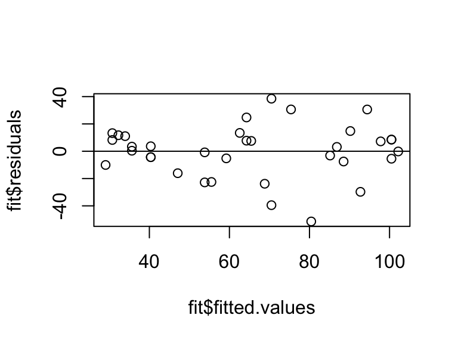

```r
# residual diagnostics: residual-fit plot
plot(fit$fitted.values, fit$residuals)
abline(h = 0)
```

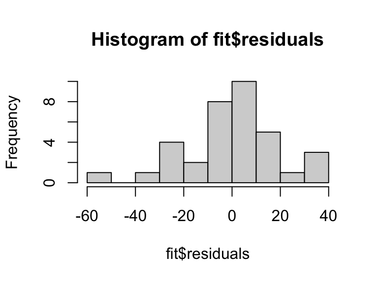

```r
# residual diagnostics: residual histogram
hist(fit$residuals)
```

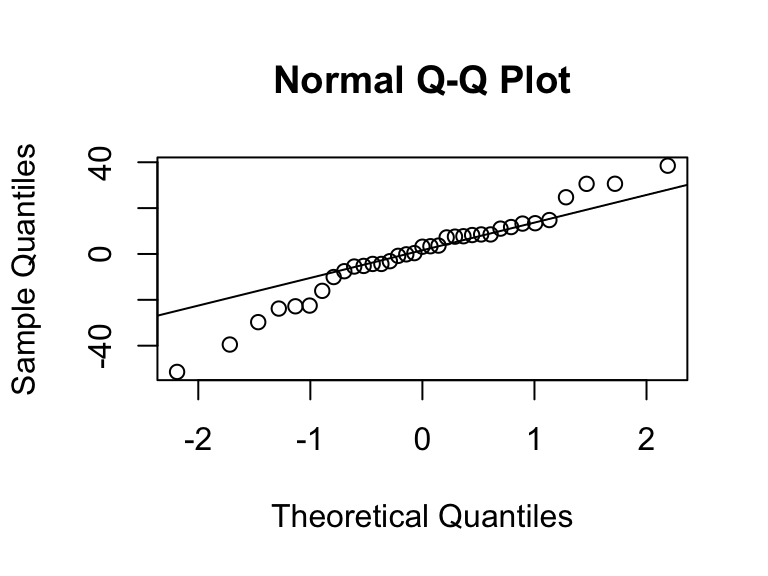

```r
# residual diagnostics: qq plot
qqnorm(fit$residuals)
qqline(fit$residuals)
```

```r
# significance tests
summary(fit)$coef
```

```
              Estimate Std. Error   t value     Pr(>|t|)
(Intercept) 162.973062 13.7265565 11.872829 1.862539e-13
Age          -1.684404  0.2294928 -7.339681 1.994774e-08
```

```r
# confidence intervals for parameter estimates
confint(fit, level = 0.95)
```

```
                 2.5 %     97.5 %
(Intercept) 135.046173 190.899951
Age          -2.151311  -1.217498
```

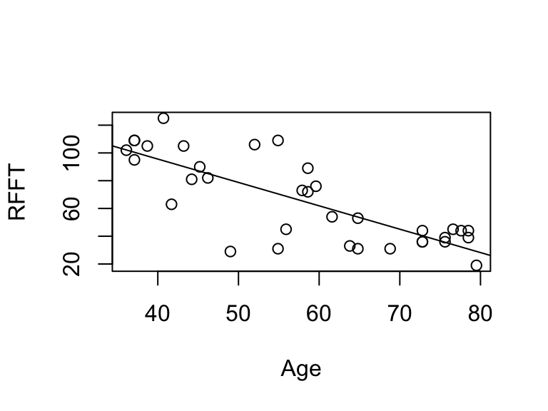

```r
# model visualization
coefs <- coef(fit)
plot(prevend)
abline(a = coefs[1], b = coefs[2])
```

We would interpret the output as indicating:

- age is significantly associated with mean RFFT (*p = 0.0000000199*)
- with 95% confidence, each year of age is associated with a decline in mean RFFT estimated to be between 1.22 and 2.15 points
- age explains 62% of variability in RFFT scores ($R^2$ = 0.6201)

## Predictions and interval estimates

While predictions *could* be computed manually from the fitted model equation, the `predict()` function will do the job given only the fitted model object and new data, formatted as a data frame. To add interval estimates, simply include either:

- `interval = 'confidence'` for an interval for the mean response
- `interval = 'prediction'` for an interval for a specific response

For example, to predict the RFFT score for a 55 year old:

```r
# point prediction
predict(fit, newdata = data.frame(Age = 55))
```

```
       1
70.33082
```

```r
# prediction interval for an observation
predict(fit, newdata = data.frame(Age = 55), interval = 'prediction')
```

```
       fit      lwr      upr
1 70.33082 30.26724 110.3944
```

```r
# confidence interval for the mean
predict(fit, newdata = data.frame(Age = 55), interval = 'confidence')
```

```
       fit      lwr      upr
1 70.33082 63.50466 77.15698
```

To visualize a specific prediction, one can simply add the prediction as a point on the plot:

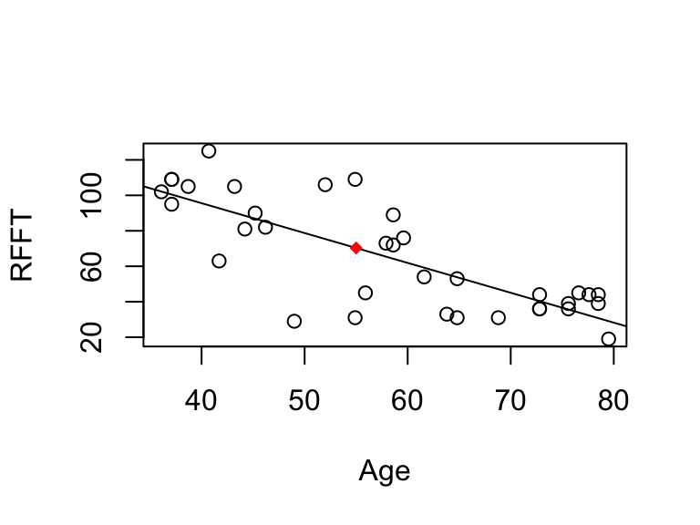

```r
# store prediction
pred <- predict(fit, newdata = data.frame(Age = 55))

# plot data, add line, add point
plot(prevend)
abline(a = coefs[1], b = coefs[2])
points(x = 55, y = pred, pch = 18, col = 'red')
```

Visualizing intervals is done by:

1. generate a grid of evenly-spaced points along the range of the explanatory variable
2. compute predictions with uncertainty quantification for each point on the grid
3. plotting a path through the upper and lower bounds

For example, to include 95% confidence intervals in the plot:

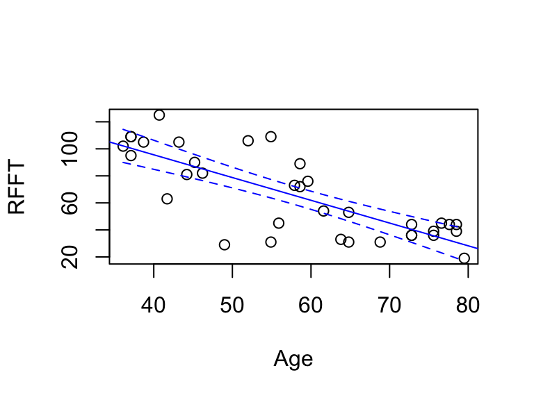

```r
# generate a grid of 100 points spanning the range of ages
x <- seq_range(prevend$Age, n = 100)

# compute predictions
preds <- predict(fit, newdata = data.frame(Age = x),
                 interval = 'confidence', level = 0.95)

# add to plot
plot(prevend)
abline(a = coefs[1], b = coefs[2], col = 'blue')
lines(x = x, y = preds[, 2], lty = 2, col = 'blue')
lines(x = x, y = preds[, 3], lty = 2, col = 'blue')
```

**Your turn**

Modify the example above to…

- visualize 99% intervals for the mean
- visualize 90% prediction intervals

```r
# generate a grid of 100 points spanning the range of ages
x <- seq_range(prevend$Age, n = 100)

# compute predictions
preds <- predict(fit, newdata = data.frame(Age = x),
                 interval = 'confidence', level = 0.95)

# add to plot
plot(prevend)
abline(a = coefs[1], b = coefs[2], col = 'blue')
lines(x = x, y = preds[, 2], lty = 2, col = 'blue')
lines(x = x, y = preds[, 3], lty = 2, col = 'blue')
```

## Practice problems

### Crab claws

Estimate the association between claw height and closing force. Predict the closing force for an individual crab with claw height 12.2; provide both point and interval estimates.

```r
# claw data
head(ex0722)

# fit model of closing force (response) against height (explanatory)

# check diagnostics

# model summary

# interval estimate for association

# prediction for claw height 12.2
```

### Galapagos Islands

Estimate the relationship between island area and the number of observed species and indicate how well your model fits the data. Provide a 95% confidence interval for the model parameter that captures the relationship and interpret the interval in context.

```r
# galapagos data
head(ex1220)

# plot total species count against area

# same, but log-transformed

# fit a model of log-total count against log-area

# check diagnostics

# check model summary for quality of fit

# compute and interpret CI for association parameter
```